# Modeling Exploration Practical 1

Elling Payne

```r
library(tidyverse);
#library(caret);
set.seed(112358);
load("out/preprocessing/data/youth_nsduh_2023_transformed.Rdata");

test.indices <- sample(1:nrow(youth_nsduh_2023_transformed),
                       size=0.2*nrow(youth_nsduh_2023_transformed));
test.data <- youth_nsduh_2023_transformed[test.indices,];
train.data <- youth_nsduh_2023_transformed[-test.indices,];

test_errs <- list();
```

```r
# function to compute overall evaluation criterion for classification trees
balanced_f1 <- function(confusion_matrix, weights) {
  #compute f1 for each class and return a weighted average
  f1_scores <- numeric(nrow(confusion_matrix));

  for (i in 1:nrow(confusion_matrix)) {
    TP <- confusion_matrix[i, i];
    FP <- sum(confusion_matrix[, i]) - TP;
    FN <- sum(confusion_matrix[i, ]) - TP;
    precision <- TP / (TP + FP);
    recall <- TP / (TP + FN);
    f1_scores[i] <- (2 * precision * recall) / (precision + recall);
     #let 0 indicate one of the classes had zero precision and recall.
    if (is.na(f1_scores[i])) f1_scores[i] <- 0;
  }

  return(c(mean(f1_scores * weights), f1_scores));
}
```

## Problem 1: Predicting whether a youth has used either cigarettes or smokeless nicotine products

An initial exploration seems to reveal that the models are not very interesting when other substance use variables are included, since these tend to over shadow others. A random forest model may be able to handle this better than a simple tree or bagged model, but for now the other substance data is omitted to focus on other factors.

### Problem 1: Final Preprocessing: subset traing and testing data.

```r
# remove other substance columns
prob1_data.train <- train.data %>%
  select(all_of(c(demographic_cols, youth_experience_cols, "TOBFLAG")));
prob1_data.test <- test.data %>%
  select(all_of(c(demographic_cols, youth_experience_cols, "TOBFLAG")));
write.csv(prob1_data.train, "out/analysis/problem1/data/train_data_problem1.csv",
          row.names=FALSE);
write.csv(prob1_data.test, "out/analysis/problem1/data/test_data_problem1.csv",
          row.names=FALSE);
```

### Problem 1: Tree and Pruned Tree Model

```r
# simple trees
library(tree);


fit.tree <- tree(TOBFLAG ~ ., data = prob1_data.train);
cv.result <- cv.tree(fit.tree, FUN=prune.misclass);
print(which.min(cv.result$dev));
```

```
## [1] 1
```

```r
pruned.tree <- prune.tree(fit.tree, best=3);
print(summary(pruned.tree));
```

```
##
## Classification tree:
## snip.tree(tree = fit.tree, nodes = 3L)
## Variables actually used in tree construction:
## [1] "FRDMJMON" "STNDSMJ"
## Number of terminal nodes:  3
## Residual mean deviance:  0.5505 = 3540 / 6430
## Misclassification error rate: 0.09296 = 598 / 6433
```

```r
png("out/analysis/problem1/plots/cverror_vs_pruning_prob1.png");
plot(cv.result$size, cv.result$dev, main="cv error vs tree size");
dev.off();
```

```r
png("out/analysis/problem1/plots/tree_pruned_prob1.png");
plot(pruned.tree);
text(pruned.tree, pretty=0);
dev.off();
```

```r
png("out/analysis/problem1/plots/tree_full_prob1.png");
plot(fit.tree);
text(fit.tree, pretty=0);
dev.off();
```

```r
print(cv.result);
```

```
## $size
## [1] 4 3 1
##
## $dev
## [1] 591 591 602
##
## $k
## [1] -Inf    0   10
##
## $method
## [1] "misclass"
##
## attr(,"class")
## [1] "prune"         "tree.sequence"
```

```r
pred <- predict(fit.tree, newdata=prob1_data.test, type="class");
conf.mat <- table(pred, prob1_data.test$TOBFLAG);
testerr <- (conf.mat[1,2] + conf.mat[2,1]) / sum(conf.mat);
# compute balanced error rate equally weighting error for each class
overall_err <- balanced_f1(conf.mat, rep(1/nrow(conf.mat), nrow(conf.mat)));
test_errs <- rbind(test_errs, data.frame(problem=1, model_type="tree",
                                         test_error=testerr, error_type="error_rate",
                                         balanced_f1=overall_err[1],
                                         class1_f1=overall_err[2],
                                         class2_f1=overall_err[3],
                                         class3_f1=NaN,
                                         log_transformed=FALSE));
pred <- predict(pruned.tree, newdata=prob1_data.test, type="class");
conf.mat <- table(pred, prob1_data.test$TOBFLAG);
testerr <- (conf.mat[1,2] + conf.mat[2,1]) / sum(conf.mat);
# compute balanced error rate equally weighting error for each class
overall_err <- balanced_f1(conf.mat, rep(1/nrow(conf.mat), nrow(conf.mat)));
test_errs <- rbind(test_errs, data.frame(problem=1, model_type="pruned_tree",
                                         test_error=testerr, error_type="error_rate",
                                         balanced_f1=overall_err[1],
                                         class1_f1=overall_err[2],
                                         class2_f1=overall_err[3],
                                         class3_f1=NaN,
                                         log_transformed=FALSE));
```

### Problem 1: Bagged ensemble model

```r
# bagged model
library(randomForest);
```

```r
fit.bag <- randomForest(TOBFLAG ~ ., data=prob1_data.train, mtry=ncol(prob1_data.train)-1,
                       importance=TRUE);
png("out/analysis/problem1/plots/error_vs_size_bagging_problem1.png");
plot(fit.bag, main="OOB Error (Total and by Group)");

legend("topright", legend = c("Total", "No Tobacco", "Tobacco"), col = 1:ncol(fit.bag$err.rate),
       lty = 1:ncol(fit.bag$err.rate), cex = 0.8);
dev.off();
```

```r
pred <- predict(fit.bag, newdata=prob1_data.test, type="class");
conf.mat <- table(pred, prob1_data.test$TOBFLAG);
testerr <- (conf.mat[1,2] + conf.mat[2,1]) / sum(conf.mat);
# compute balanced error rate equally weighting error for each class
overall_err <- balanced_f1(conf.mat, rep(1/nrow(conf.mat), nrow(conf.mat)));
test_errs <- rbind(test_errs, data.frame(problem=1, model_type="bagging",
                                         test_error=testerr, error_type="error_rate",
                                         balanced_f1=overall_err[1],
                                         class1_f1=overall_err[2],
                                         class2_f1=overall_err[3],
                                         class3_f1=NaN,log_transformed=FALSE));
```

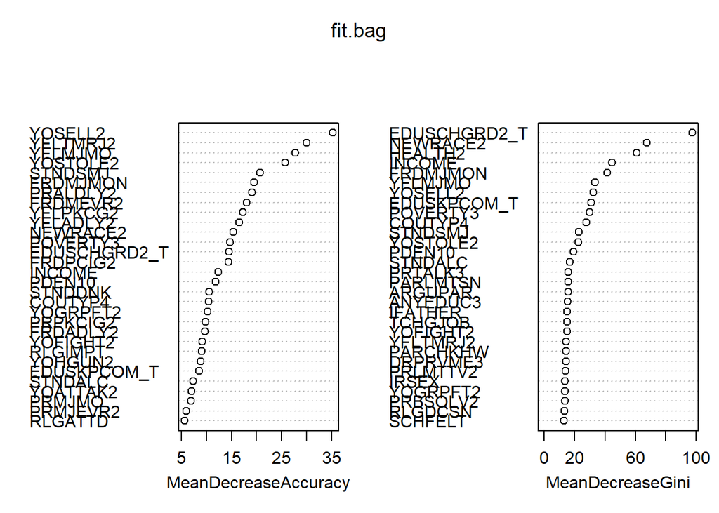

```r
varImpPlot(fit.bag);
```

```r
imp_bag <- importance(fit.bag)[order(importance(fit.bag)[, 4], decreasing=TRUE),];
write.csv(imp_bag, "out/analysis/problem1/data/rel_import_bagging_problem1.csv",
          row.names=TRUE);
```

### Problem 1: Random Forest Model

```r
# tuning based on OOB overall error
tune.result <- tuneRF(x=prob1_data.train %>% select(-TOBFLAG),
                      y=prob1_data.train$TOBFLAG,
                      mtryStart=floor(sqrt(ncol(prob1_data.train)-1)),
                      stepFactor=1.2,
                      improve=0.001,
                      ntreeTry=100,);
```

```
## mtry = 7  OOB error = 9.02%
## Searching left ...
## mtry = 6     OOB error = 9.12%
## -0.01206897 0.001
## Searching right ...
## mtry = 8     OOB error = 9.4%
## -0.04310345 0.001
```

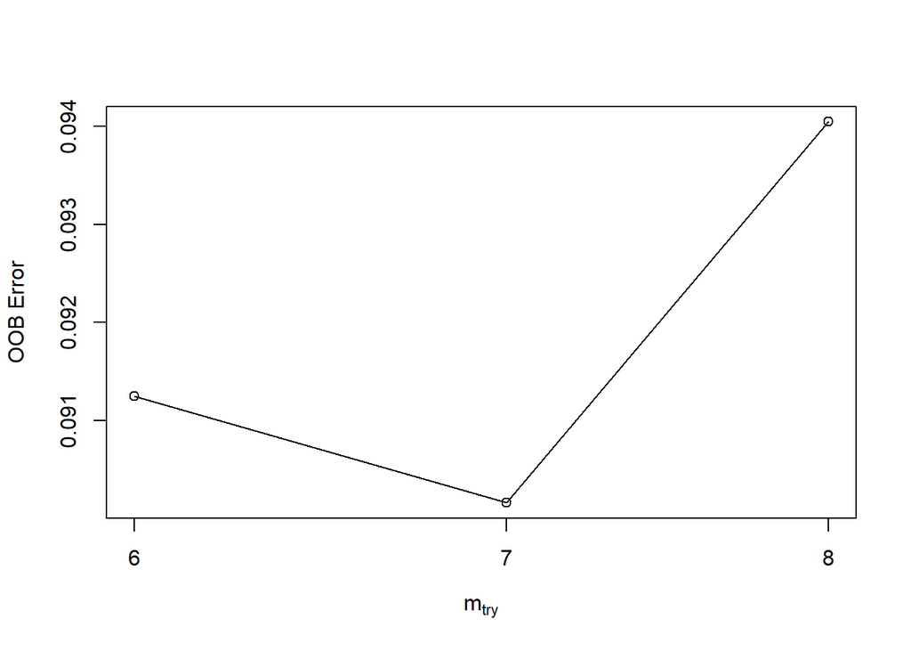

```r
mtry_vals <- tune.result[, 1];
oob_errs <- tune.result[, 2];
png("out/analysis/problem1/plots/OOB_error_vs_mtry_randforest_problem1.png");
plt <- ggplot(mapping=aes(x = mtry_vals, y = oob_errs)) +
  geom_line(color = "skyblue") +
  geom_point(color = "red", size = 3) +
  labs(title = "mtry vs OOB Error",
       x = "mtry",
       y = "OOB Error");
print(plt);
dev.off();
```

```r
best.mtry <- tune.result[which.min(tune.result[,2]), 1];
print(paste0("Best choice of mtry based on OOB error is ", best.mtry));
```

```
## [1] "Best choice of mtry based on OOB error is 7"
```

```r
best.rf <- randomForest(TOBFLAG ~ ., data=prob1_data.train, mtry=best.mtry,
                           importance=TRUE);
png("out/analysis/problem1/plots/error_vs_size_randforest_problem1.png");
plot(best.rf, main="OOB Error (Total and by Group)");

legend("topright", legend = c("Total", "No Tobacco", "Tobacco"), col = 1:ncol(best.rf$err.rate),
       lty = 1:ncol(best.rf$err.rate), cex = 0.8);
dev.off();
```

```r
pred <- predict(best.rf, newdata=prob1_data.test, type="class");
conf.mat <- table(pred, prob1_data.test$TOBFLAG);
testerr <- (conf.mat[1,2] + conf.mat[2,1]) / sum(conf.mat);
# compute balanced error rate equally weighting error for each class
overall_err <- balanced_f1(conf.mat, rep(1/nrow(conf.mat), nrow(conf.mat)));
test_errs <- rbind(test_errs, data.frame(problem=1, model_type="random_forest",
                                         test_error=testerr, error_type="error_rate",
                                         balanced_f1=overall_err[1],
                                         class1_f1=overall_err[2],
                                         class2_f1=overall_err[3],
                                         class3_f1=NaN, log_transformed=FALSE));
```

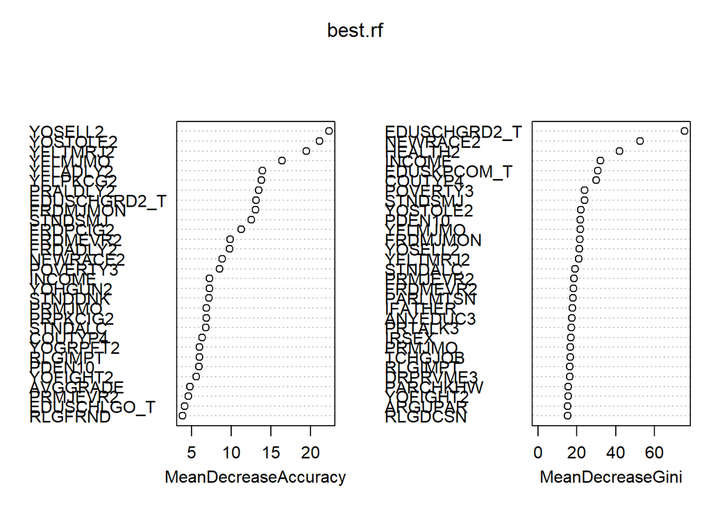

```r
varImpPlot(best.rf);
```

```r
relimp <- importance(best.rf)[order(importance(fit.bag)[, 4], decreasing=TRUE),];
write.csv(relimp, "out/analysis/problem1/data/rel_import_randforest_problem1.csv",
          row.names=TRUE);
```

## Problem 2: Predicting whether a youth drinks alcohol never, seldom, or often

### Problem 2: final preprocessing

Since there was the classes in ALCYDAYS are heavily imbalanced, with the class representing no usage having much higher membership than the others, it was decided to transform ALCYDAYS by keeping the never used category and the lowest usage categories but combining all the others. The result is fewer classes “Never”, “Seldom”, and “Moderate/Often”. While the imbalance remains, there is greater membership in the new combined class than the individual high usage classes. This may improve the model’s ability to learn rules that result in predicting the new combined class, compared with the individual original classes.

```r
# remove alc and irrelevant columns, all other substance columns
prob2_data.train <- train.data %>%
  select(all_of(c(demographic_cols, youth_experience_cols, "ALCYDAYS"))) %>%
  mutate(ALCYFREQ = as.factor(ifelse(ALCYDAYS == 0, "Never",
                              ifelse(ALCYDAYS == 1, "Seldom", "Moderate/Often")))) %>%
                    select(-ALCYDAYS);
prob2_data.test <- test.data %>%
  select(all_of(c(demographic_cols, youth_experience_cols, "ALCYDAYS"))) %>%
  mutate(ALCYFREQ = as.factor(ifelse(ALCYDAYS == 0, "Never",
                              ifelse(ALCYDAYS == 1, "Seldom", "Moderate/Often")))) %>%
                    select(-ALCYDAYS);
write.csv(prob2_data.train, "out/analysis/problem2/data/train_data_problem2.csv",
          row.names=FALSE);
write.csv(prob2_data.test, "out/analysis/problem2/data/test_data_problem2.csv",
          row.names=FALSE);
```

### Problem 2: Tree and Pruned Tree Models

```r
# simple trees
library(tree);


fit.tree <- tree(ALCYFREQ ~ ., data = prob2_data.train);
cv.result <- cv.tree(fit.tree, FUN=prune.misclass);
print(which.min(cv.result$dev));
```

```
## [1] 1
```

```r
pruned.tree <- prune.tree(fit.tree, best=3);
print(summary(pruned.tree));
```

```
##
## Classification tree:
## snip.tree(tree = fit.tree, nodes = 2L)
## Variables actually used in tree construction:
## [1] "STNDALC"  "YFLTMRJ2"
## Number of terminal nodes:  3
## Residual mean deviance:  1.116 = 7175 / 6430
## Misclassification error rate: 0.1976 = 1271 / 6433
```

```r
png("out/analysis/problem2/plots/cverror_vs_pruning_prob2.png");
plot(cv.result$size, cv.result$dev, main="cv error vs tree size");
dev.off();
```

```r
png("out/analysis/problem2/plots/tree_pruned_prob2.png");
plot(pruned.tree);
text(pruned.tree, pretty=0);
dev.off();
```

```r
png("out/analysis/problem2/plots/tree_full_prob2.png");
plot(fit.tree);
text(fit.tree, pretty=0);
dev.off();
```

```r
print(cv.result);
```

```
## $size
## [1] 4 1
##
## $dev
## [1] 1271 1271
##
## $k
## [1] -Inf    0
##
## $method
## [1] "misclass"
##
## attr(,"class")
## [1] "prune"         "tree.sequence"
```

```r
pred <- predict(fit.tree, newdata=prob2_data.test, type="class");
conf.mat <- table(pred, prob2_data.test$ALCYFREQ);
testerr <- 1- (sum(diag(conf.mat)) / sum(conf.mat));
# compute balanced error rate equally weighting error for each class
overall_err <- balanced_f1(conf.mat, rep(1/nrow(conf.mat), nrow(conf.mat)));
test_errs <- rbind(test_errs, data.frame(problem=2, model_type="tree",
                                         test_error=testerr, error_type="error_rate",
                                         balanced_f1=overall_err[1],
                                         class1_f1=overall_err[2],
                                         class2_f1=overall_err[3],
                                         class3_f1=overall_err[4], log_transformed=FALSE));
pred <- predict(pruned.tree, newdata=prob2_data.test, type="class");
conf.mat <- table(pred, prob2_data.test$ALCYFREQ);
testerr <- 1- (sum(diag(conf.mat)) / sum(conf.mat));
# compute balanced error rate equally weighting error for each class
overall_err <- balanced_f1(conf.mat, rep(1/nrow(conf.mat), nrow(conf.mat)));
test_errs <- rbind(test_errs, data.frame(problem=2, model_type="pruned_tree",
                                         test_error=testerr, error_type="error_rate",
                                         balanced_f1=overall_err[1],
                                         class1_f1=overall_err[2],
                                         class2_f1=overall_err[3],
                                         class3_f1=overall_err[4], log_transformed=FALSE));
```

### Problem 2: Random Forest Model

```r
# random forests tuning based on OOB overall error
tune.result <- tuneRF(x=prob2_data.train %>% select(-ALCYFREQ),
                      y=prob2_data.train$ALCYFREQ,
                      mtryStart=floor(sqrt(ncol(prob2_data.train)-1)),
                      stepFactor=1.2,
                      improve=0.001,
                      ntreeTry=100,);
```

```
## mtry = 7  OOB error = 19.18%
## Searching left ...
## mtry = 6     OOB error = 18.92%
## 0.01377634 0.001
## mtry = 5     OOB error = 19.18%
## -0.01396878 0.001
## Searching right ...
## mtry = 8     OOB error = 19.31%
## -0.02054232 0.001
```

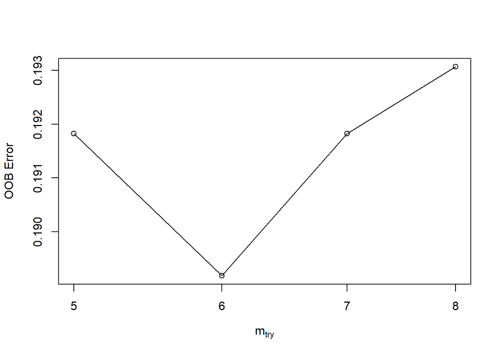

```r
mtry_vals <- tune.result[, 1];
oob_errs <- tune.result[, 2];
png("out/analysis/problem2/plots/OOB_error_vs_mtry_randforest_problem2.png");
plt <- ggplot(mapping=aes(x = mtry_vals, y = oob_errs)) +
  geom_line(color = "skyblue") +
  geom_point(color = "red", size = 3) +
  labs(title = "mtry vs OOB Error",
       x = "mtry",
       y = "OOB Error");
print(plt);
dev.off();
```

```r
best.mtry <- tune.result[which.min(tune.result[,2]), 1];
print(paste0("Best choice of mtry based on OOB error is ", best.mtry));
```

```
## [1] "Best choice of mtry based on OOB error is 6"
```

```r
best.rf <- randomForest(ALCYFREQ ~ ., data=prob2_data.train, mtry=best.mtry,
                           importance=TRUE);
png("out/analysis/problem2/plots/error_vs_size_randforest_problem2.png");
plot(best.rf, main="OOB Error (Total and by Group)");

legend("topright", legend = colnames(best.rf$err.rate), col = 1:ncol(best.rf$err.rate),
       lty = 1:ncol(best.rf$err.rate), cex = 0.8);
dev.off();
```

```r
pred <- predict(best.rf, newdata=prob2_data.test, type="class");
conf.mat <- table(pred, prob2_data.test$ALCYFREQ);
testerr <- testerr <- 1 - (sum(diag(conf.mat)) / sum(conf.mat));
# compute balanced error rate equally weighting error for each class
overall_err <- balanced_f1(conf.mat, rep(1/nrow(conf.mat), nrow(conf.mat)));
test_errs <- rbind(test_errs, data.frame(problem=2, model_type="random_forest",
                                         test_error=testerr, error_type="error_rate",
                                         balanced_f1=overall_err[1],
                                         class1_f1=overall_err[2],
                                         class2_f1=overall_err[3],
                                         class3_f1=overall_err[4], log_transformed=FALSE));
```

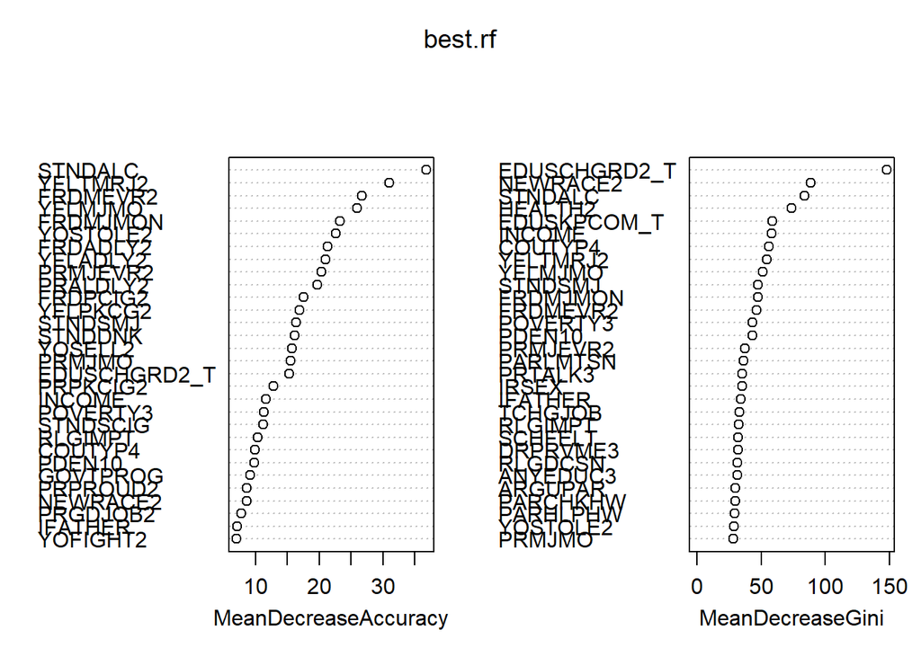

```r
varImpPlot(best.rf);
```

```r
rel_imp <- importance(best.rf)[order(importance(best.rf)[, 4], decreasing=TRUE),];
print(rel_imp);
```

```
##              Moderate/Often      Never       Seldom MeanDecreaseAccuracy
## STNDALC         24.59619869 28.4207673  14.85239320          36.79914025
## YFLTMRJ2         3.91579153 30.3050606   2.80582057          31.01124704
## FRDMEVR2        11.37709686 25.2750208  -2.01304856          26.68171434
## YFLMJMO          8.28997402 24.9183195  -1.99969146          25.93298431
## FRDMJMON        12.02638201 20.5092245   3.60321071          23.24665948
## YOSTOLE2        14.14725905 19.7121271   0.80038911          22.56390430
## FRDADLY2         8.47946864 21.4977477  -9.21091989          21.27895913
## YFLADLY2         6.38460208 21.3490604  -9.52234010          20.99842428
## PRMJEVR2         8.91198962 19.7204209  -4.06014553          20.30834325
## PRALDLY2        11.08185617 18.8050248  -3.24211953          19.68540900
## FRDPCIG2        -2.78916154 19.2444117  -4.82821319          17.50689900
## YFLPKCG2        -5.75844170 19.4081809  -6.67527064          16.87648185
## STNDSMJ          9.41436671 13.3246993   4.24138236          16.40061316
## STNDDNK          6.37639206 16.2713588  -3.92870141          16.15204764
## YOSELL2          8.80329401 14.6522508  -2.48062509          15.72675534
## PRMJMO          11.27492755 15.4715936 -10.26270521          15.51311310
## EDUSCHGRD2_T    10.87651397  9.6123432   8.63656379          15.30731958
## PRPKCIG2         0.82243843 13.4898621  -3.05614077          12.81418348
## INCOME           3.44717458 10.4335741   2.64590775          11.59001201
## POVERTY3         2.34150973  9.9034441   2.08396532          11.24806941
## STNDSCIG         2.05038425 11.1109293  -0.56228514          11.16798440
## RLGIMPT          1.92483336  9.4941311   2.07682498          10.37922876
## COUTYP4          3.30694320 10.1599919  -1.71029219           9.89442516
## PDEN10           2.70638001 10.3489176  -2.22816759           9.75479936
## GOVTPROG         2.65623361  8.7939815  -0.23646154           9.14008855
## PRPROUD2         0.77200892  9.3105497   0.23953493           8.65021951
## NEWRACE2         0.42954610  8.3036697   2.04745764           8.56448938
## PRGDJOB2         3.08307524  6.7577933   1.15114027           7.76869627
## IFATHER          3.34190453  6.8332836   0.02076555           7.07216467
## YOFIGHT2         1.00085331  7.9916448  -1.08880703           6.99036148
## YOGRPFT2         3.05880922  4.4915980   3.27721708           6.11108805
## RLGATTD          0.20694266  5.6011221   2.23847577           5.93793065
## YOATTAK2         2.01142139  4.4167562   1.48161171           5.15368562
## RLGDCSN         -1.53174928  3.4966190   3.42043441           4.13347198
## PARHLPHW         1.10931423  3.4165746   2.31899512           4.02918373
## TALKPROB         0.83970455  4.1215964  -1.54087501           3.62912458
## PREGPGM2         0.62001813  3.0272402   1.97708370           3.51799728
## PARLMTSN        -0.20892408  3.5474677   0.28671901           3.10397239
## YOHGUN2          6.19807955  1.1827033  -0.43352565           3.10075773
```

[output cut: 67 more lines]

```
## SCHFELT             32.230837
## IRSEX               35.381657
## PRBSOLV2            25.841486
## PRLMTTV2            27.568283
## EDUSCHLGO_T         13.122286
## PRVDRGO2            13.746626
## DRPRVME3            32.175498
## TCHGJOB             32.947942
## AVGGRADE            12.978397
## IMOTHER             20.456375
## YTHACT2             24.298120
## PRCHORE2            22.241079
## ARGUPAR             30.077889
## ANYEDUC3            31.300229
## PREVIOL2            11.202543
```

```r
write.csv(rel_imp, "out/analysis/problem2/data/rel_imp_randforest_problem2.csv",
          row.names = TRUE);
```

## Problem 3: Predicting the number of days a youth used marijuana in the past year

### Problem 3: Final Preprocessing

Since EDA identified a heavy right skew and nonnormality in the response variable, IRMJFY, a model built on a log-transformation of IRMJFY will be compared to that built on the original variable. Since zeros are present in the data, the transformation requires nudging to ensure that zeros may be transformed. Then, where possible, the reverse transformation was applied to predictions on the test and error set so that validation set error may be properly compared between the models.

```r
# remove all other substance columns
# add log transformation to reduce skew and compare to model on un transformed variable

prob3_data.train <- train.data %>%
  mutate(log_IRMJFY = log(IRMJFY + 0.001)) %>%
  select(all_of(c(demographic_cols, youth_experience_cols, "IRMJFY", "log_IRMJFY")));

prob3_data.test <- test.data %>%
  mutate(log_IRMJFY = log(IRMJFY + 0.001)) %>%
  select(all_of(c(demographic_cols, youth_experience_cols, "IRMJFY", "log_IRMJFY")));
write.csv(prob3_data.train, "out/analysis/problem3/data/train_data_problem3.csv",
          row.names=FALSE);
write.csv(prob3_data.test, "out/analysis/problem3/data/test_data_problem3.csv",
          row.names=FALSE);
```

### Problem 3: Tree and Pruned Tree Models

Modeling on original past year days of marijuana use (IRMJFY):

```r
# simple tree
library(tree);


fit.tree <- tree(IRMJFY ~ . - log_IRMJFY, data = prob3_data.train);
cv.result <- cv.tree(fit.tree, FUN=prune.tree);
print(which.min(cv.result$dev));
```

```
## [1] 1
```

```r
pruned.tree <- prune.tree(fit.tree, best=6);
print(summary(pruned.tree));
```

```
##
## Regression tree:
## snip.tree(tree = fit.tree, nodes = 29L)
## Variables actually used in tree construction:
## [1] "FRDMJMON"    "YOSELL2"     "EDUSKPCOM_T" "STNDSMJ"     "PRMJEVR2"
## Number of terminal nodes:  6
## Residual mean deviance:  2044 = 13140000 / 6427
## Distribution of residuals:
##     Min.  1st Qu.   Median     Mean  3rd Qu.     Max.
## -242.900   -3.416   -3.416    0.000   -3.416  361.600
```

```r
png("out/analysis/problem3/plots/cverror_vs_pruning_prob3.png");
plot(cv.result$size, cv.result$dev, main="cv error vs tree size");
dev.off();
```

```r
png("out/analysis/problem3/plots/tree_pruned_prob3.png");
plot(pruned.tree);
text(pruned.tree, pretty=0);
dev.off();
```

```r
png("out/analysis/problem3/plots/tree_full_prob3.png");
plot(fit.tree);
text(fit.tree, pretty=0);
dev.off();
```

```r
print(cv.result);
```

```
## $size
## [1] 8 7 6 5 4 3 2 1
##
## $dev
## [1] 13521712 13561546 13532748 13969911 13969911 14306690 15337984 17174877
##
## $k
## [1]      -Inf  172353.9  187830.2  299837.5  307082.1  510651.2 1073124.5
## [8] 1843128.6
##
## $method
## [1] "deviance"
##
## attr(,"class")
## [1] "prune"         "tree.sequence"
```

```r
pred <- predict(fit.tree, newdata=prob3_data.test);
testerr <- mean((pred - prob3_data.test$IRMJFY)^2);
test_errs <- rbind(test_errs, data.frame(problem=3, model_type="tree",
                                         test_error=testerr, error_type="mse",
                                         balanced_f1=NaN,
                                         class1_f1=NaN,
                                         class2_f1=NaN,
                                         class3_f1=NaN, log_transformed=FALSE));
pred <- predict(pruned.tree, newdata=prob3_data.test);
testerr <- mean((pred - prob3_data.test$IRMJFY)^2);
test_errs <- rbind(test_errs, data.frame(problem=3, model_type="pruned_tree",
                                         test_error=testerr, error_type="mse",
                                         balanced_f1=NaN,
                                         class1_f1=NaN,
                                         class2_f1=NaN,
                                         class3_f1=NaN, log_transformed=FALSE));
```

Modeling on log-transformed past year days of marijuana use (log_IRMJFY):

```r
# tree for log_IRMJFY
fit.tree <- tree(log_IRMJFY ~ . - IRMJFY, data = prob3_data.train);
cv.result <- cv.tree(fit.tree, FUN=prune.tree);
print(which.min(cv.result$dev));
```

```
## [1] 1
```

```r
pruned.tree <- prune.tree(fit.tree, best=6);
print(summary(pruned.tree));
```

```
##
## Regression tree:
## snip.tree(tree = fit.tree, nodes = 4L)
## Variables actually used in tree construction:
## [1] "FRDMJMON" "STNDSMJ"  "YFLMJMO"  "YOSELL2"
## Number of terminal nodes:  6
## Residual mean deviance:  8.903 = 57220 / 6427
## Distribution of residuals:
##     Min.  1st Qu.   Median     Mean  3rd Qu.     Max.
## -10.8900  -1.7620  -0.2385   0.0000  -0.2385  12.5700
```

```r
png("out/analysis/problem3/plots/cverror_vs_pruning_prob3_logtransformed.png");
plot(cv.result$size, cv.result$dev, main="cv error vs tree size");
dev.off();
```

```r
png("out/analysis/problem3/plots/tree_pruned_prob3_logtransformed.png");
plot(pruned.tree);
text(pruned.tree, pretty=0);
dev.off();
```

```r
png("out/analysis/problem3/plots/tree_full_prob3_logtransformed.png");
plot(fit.tree);
text(fit.tree, pretty=0);
dev.off();
```

```r
print(cv.result);
```

```
## $size
## [1] 7 6 5 4 3 2 1
##
## $dev
## [1] 58959.38 59134.91 59134.91 59993.30 61587.36 65409.09 81334.39
##
## $k
## [1]       -Inf   859.4818   867.9676  1490.2016  1876.7486  3859.3137 16011.7569
##
## $method
## [1] "deviance"
##
## attr(,"class")
## [1] "prune"         "tree.sequence"
```

```r
#predict and undo log transformation for apples to apples comparison
pred <- exp(predict(fit.tree, newdata=prob3_data.test)) - 0.001;
testerr <- mean((pred - prob3_data.test$IRMJFY)^2);
test_errs <- rbind(test_errs, data.frame(problem=3, model_type="tree",
                                         test_error=testerr, error_type="mse",
                                         balanced_f1=NaN,
                                         class1_f1=NaN,
                                         class2_f1=NaN,
                                         class3_f1=NaN, log_transformed=TRUE));
pred <- predict(pruned.tree, newdata=prob3_data.test) - 0.001;
testerr <- mean((pred - prob3_data.test$IRMJFY)^2);
test_errs <- rbind(test_errs, data.frame(problem=3, model_type="pruned_tree",
                                         test_error=testerr, error_type="mse",
                                         balanced_f1=NaN,
                                         class1_f1=NaN,
                                         class2_f1=NaN,
                                         class3_f1=NaN, log_transformed=TRUE));
```

### Problem 3: Boosted Tree Ensembles

Modeling on original past year days of marijuana use (IRMJFY):

```r
# boosted models
tune.grid <- expand.grid( ntrees = c(25, 50, 100, 150),
                          depth = 1:3,
                          shrinkage =c(0.001, 0.01, 0.05, 0.1));
```

```r
library(gbm);
```

```r
param_tune.results <- data.frame(tune.grid);
cv.scores <- numeric(nrow(tune.grid));
train.errs <- numeric(nrow(tune.grid));
gbmtest.errs <- numeric(nrow(tune.grid));
for (r in 1:nrow(tune.grid)) {
  fit.gbm <- gbm(IRMJFY ~ . - log_IRMJFY, data=prob3_data.train, distribution="gaussian",
                 cv.folds=5, verbose=FALSE,
                 n.trees = tune.grid[r, "ntrees"],
                 interaction.depth = tune.grid[r, "depth"],
                 shrinkage = tune.grid[r, "shrinkage"]);
  cv.scores[r] <- fit.gbm$cv.error[length(fit.gbm$cv.error)];
  train.errs[r] <- fit.gbm$train.error[length(fit.gbm$train.error)];
  pred <- predict(fit.gbm, newdata=prob3_data.test, n.trees=tune.grid[r, "ntrees"]);
  gbmtest.errs[r] <- mean((pred - prob3_data.test$IRMJFY)^2);
}
param_tune.results$cv_error <- cv.scores; # for choosing
param_tune.results$train_error <- train.errs; # for plotting
param_tune.results$test_error <- gbmtest.errs; # for plotting
```

```r
# Choose best parameter combination based on CV score
best.params <- param_tune.results[which.min(cv.scores),];
best.gbm <- gbm(IRMJFY ~ . - log_IRMJFY, data=prob3_data.train, distribution="gaussian",
                verbose=FALSE,
                n.trees = best.params[["ntrees"]],
                interaction.depth = best.params[["depth"]],
                shrinkage = best.params[["shrinkage"]]);

pred <- predict(best.gbm, newdata=prob3_data.test, n.trees=best.params[["ntrees"]]);
testerr <- mean((pred - prob3_data.test$IRMJFY)^2);
test_errs <- rbind(test_errs, data.frame(problem=3, model_type="boosting",
                                         test_error=testerr, error_type="mse",
                                         balanced_f1=NaN,
                                         class1_f1=NaN,
                                         class2_f1=NaN,
                                         class3_f1=NaN, log_transformed=FALSE));

print(best.params);
```

```
##    ntrees depth shrinkage cv_error train_error test_error
## 47    100     3       0.1 1932.262      1645.1   1967.547
```

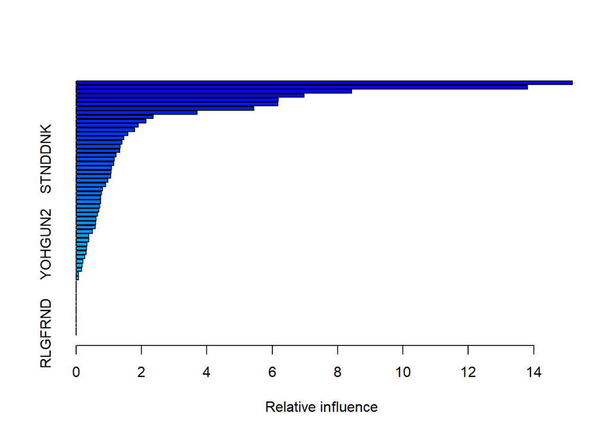

```r
write.csv(summary(best.gbm), "out/analysis/problem3/data/rel_import_boosting_problem3.csv",
          row.names = TRUE);
```

Modeling on log-transformed past year days of marijuana use (log_IRMJFY):

```r
param_tune.logtransformed <- data.frame(tune.grid);
cv.scores <- numeric(nrow(tune.grid));
train.errs <- numeric(nrow(tune.grid));
gbmtest.errs <- numeric(nrow(tune.grid));
for (r in 1:nrow(tune.grid)) {
  fit.gbm <- gbm(log_IRMJFY ~ . - IRMJFY, data=prob3_data.train, distribution="gaussian",
                 cv.folds=5, verbose=FALSE,
                 n.trees = tune.grid[r, "ntrees"],
                 interaction.depth = tune.grid[r, "depth"],
                 shrinkage = tune.grid[r, "shrinkage"]);

  # used for tuning, log tansform not undone
  cv.scores[r] <- fit.gbm$cv.error[length(fit.gbm$cv.error)];
  train.pred <- exp(predict(fit.gbm, n.trees=tune.grid[r, "ntrees"])) - 0.001;
  #train.errs[r] <- fit.gbm$train.error[length(fit.gbm$train.error)];
  train.errs[r] <- mean((train.pred - prob3_data.train$IRMJFY)^2);
  pred <- exp(predict(fit.gbm, newdata=prob3_data.test, n.trees=tune.grid[r, "ntrees"])) - 0.001;
  gbmtest.errs[r] <- mean((pred - prob3_data.test$IRMJFY)^2);
}
param_tune.logtransformed$cv_error <- cv.scores; # for choosing
param_tune.logtransformed$train_error <- train.errs; # for plotting
param_tune.logtransformed$test_error <- gbmtest.errs; # for plotting

# Choose best parameter combination based on CV score
best.params <- param_tune.logtransformed[which.min(cv.scores),];
best.gbm.log <- gbm(log_IRMJFY ~ . - IRMJFY, data=prob3_data.train, distribution="gaussian",
                verbose=FALSE,
                n.trees = best.params[["ntrees"]],
                interaction.depth = best.params[["depth"]],
                shrinkage = best.params[["shrinkage"]]);

pred <- predict(best.gbm.log, newdata=prob3_data.test, n.trees=best.params[["ntrees"]]);
testerr <- mean((pred - prob3_data.test$IRMJFY)^2);
test_errs <- rbind(test_errs, data.frame(problem=3, model_type="boosting",
                                         test_error=testerr, error_type="mse",
                                         balanced_f1=NaN,
                                         class1_f1=NaN,
                                         class2_f1=NaN,
                                         class3_f1=NaN, log_transformed=TRUE));

print(best.params);
```

```
##    ntrees depth shrinkage cv_error train_error test_error
## 48    150     3       0.1 7.880457    3818.627   52498.54
```

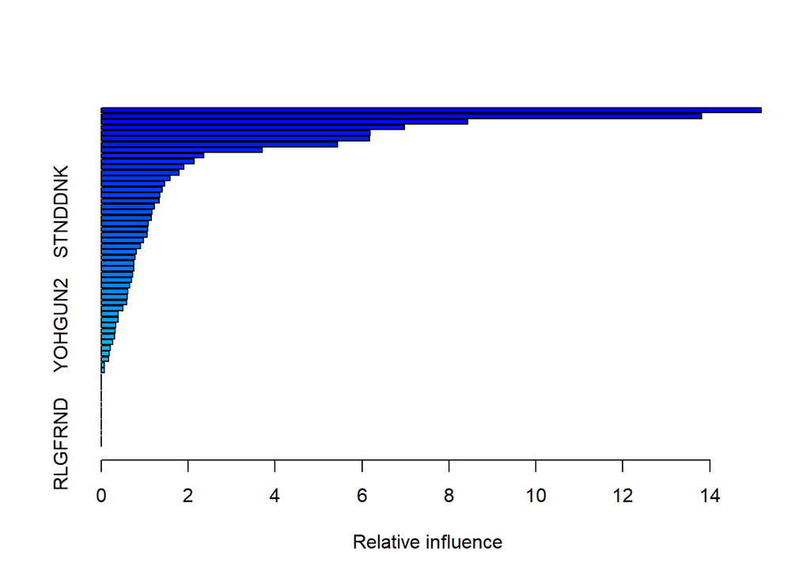

```r
write.csv(summary(best.gbm), "out/analysis/problem3/data/rel_import_boosting_problem3_logtransformed.csv",
          row.names = TRUE);
```

```r
# tuning plots
plot_tuning <- function(tuning_data, curr_tuner, err_metrics, other_tuners, output_dir,
                        suffix) {
  # Unique combinations of the other parameters
  unique_combinations <- unique(tuning_data[other_tuners])

  for (i in 1:nrow(unique_combinations)) {
    # Filter data for the current combination of other tuners
    filter_conditions <- Map(function(col, val) tuning_data[[col]] == val,
                             names(unique_combinations), unique_combinations[i, ])
    filtered_data <- tuning_data[Reduce(`&`, filter_conditions), ]

    plot <- ggplot(filtered_data, aes_string(x = curr_tuner)) +
      geom_line(aes_string(y = err_metrics[1], color = shQuote(err_metrics[1]))) +
      geom_line(aes_string(y = err_metrics[2], color = shQuote(err_metrics[2]))) +
      geom_line(aes_string(y = err_metrics[3], color = shQuote(err_metrics[3]))) +
      labs(
        title = paste("Error Metrics vs", curr_tuner, "for",
                      paste(names(unique_combinations), unique_combinations[i, ],
                            sep = "=", collapse = ", ")),
        x = curr_tuner,
        y = "Error Metrics") +
      scale_color_manual(values = c("cv_error" = "coral", "train_error" = "skyblue",
                                    "test_error" = "green"));

    filename <- paste0(output_dir, curr_tuner, "_error_plot_", paste(names(unique_combinations), unique_combinations[i, ], sep = "", collapse = "_"), suffix, ".png");
    ggsave(filename, plot = plot);
  }
}
```

```
## [1] 329537.5
```

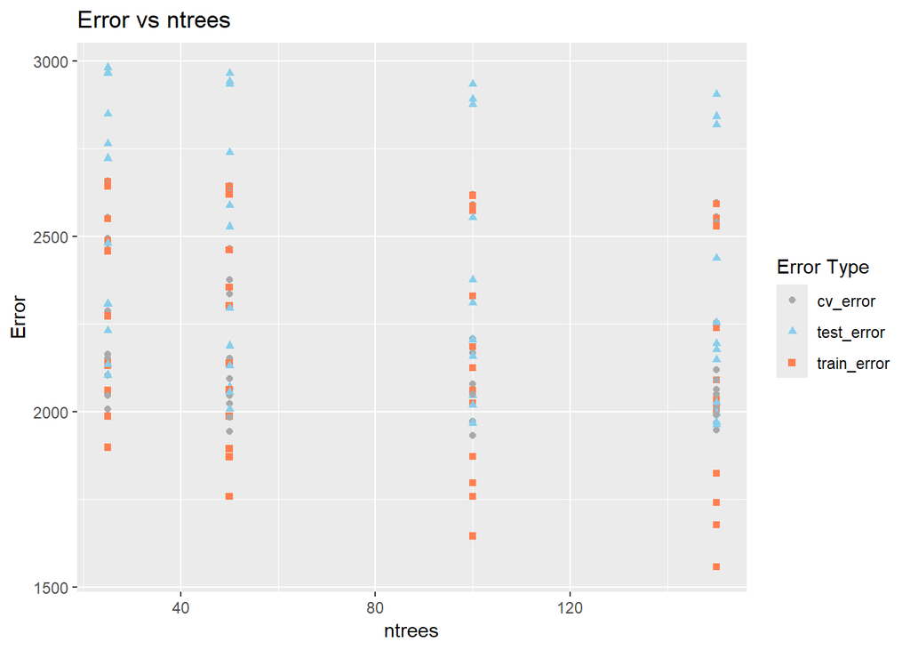

```
## [1] 329537.5
```

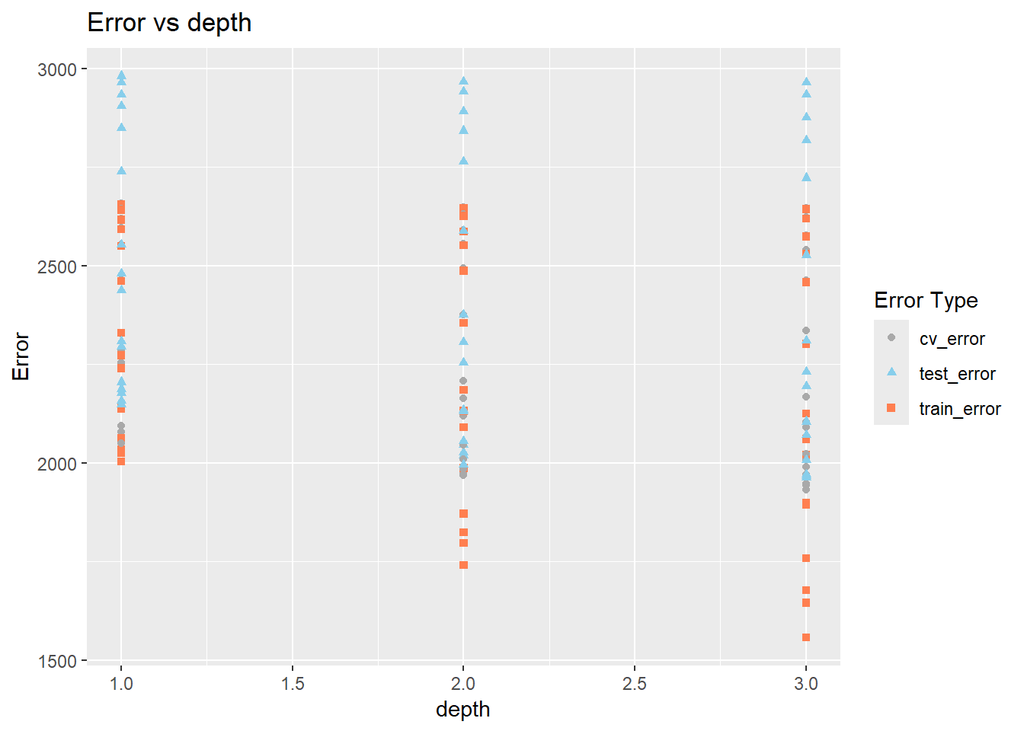

```
## [1] 329537.5
```

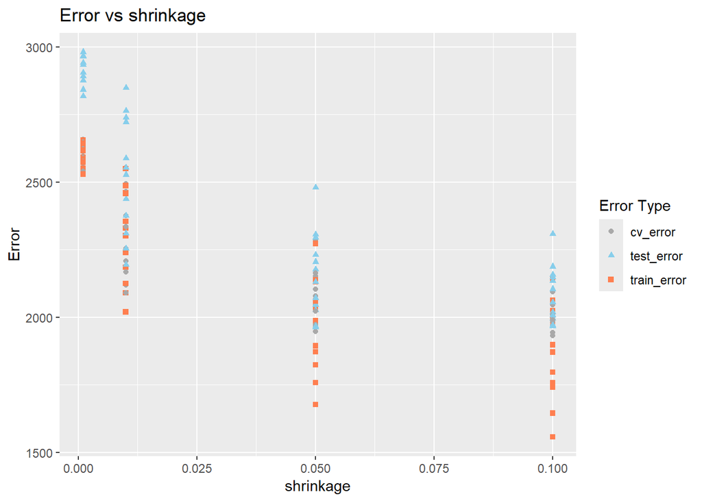

```r
# Generate plots for each parameter
output_dir <- "out/analysis/problem3/";
y_vars <- c("cv_error", "train_error", "test_error");
plot_tuning(param_tune.results, "ntrees", y_vars, c("depth", "shrinkage"), output_dir, "");
plot_tuning(param_tune.results, "depth", y_vars, c("ntrees", "shrinkage"), output_dir, "");
plot_tuning(param_tune.results, "shrinkage", y_vars, c("ntrees", "depth"), output_dir, "");
plot_tuning(param_tune.logtransformed, "ntrees", y_vars, c("depth", "shrinkage"), output_dir,
            "_logtransformed");
plot_tuning(param_tune.logtransformed, "depth", y_vars, c("ntrees", "shrinkage"), output_dir,
            "_logtransformed");
plot_tuning(param_tune.logtransformed, "shrinkage", y_vars, c("ntrees", "depth"), output_dir,
            "_logtransformed");
# write dataframes containing tuning results
write.csv(param_tune.results, "out/analysis/problem3/params_and_errs_boosting_problem3.csv",
          row.names = FALSE);
write.csv(param_tune.logtransformed,
          "out/analysis/problem3/params_and_errs_boosting_problem3_logtransformed.csv",
          row.names = FALSE);
tuners <- c("ntrees", "depth", "shrinkage");

#overall plot of tuners vs errs
for (param in tuners) {
  plot_data <- param_tune.results %>%
    mutate(thisparam=param_tune.results[[param]]) %>% select(-all_of(tuners)) %>%
    pivot_longer(cols=c("cv_error", "train_error", "test_error"),
                 names_to = "Error_Type",
                 values_to = "Error") %>%
    mutate(Error_Type = as.factor(Error_Type));
  print(sum(plot_data$Error));
  plt <- ggplot(data=plot_data, mapping=aes(x=thisparam, y=Error,
                                            color=Error_Type,
                                            shape=Error_Type)) +
    geom_point() +
    labs(title = paste0("Error vs ", param),
         x=param, y="Error",
         color="Error Type",
         shape="Error Type") +
    scale_color_manual(values = c("darkgrey", "skyblue", "coral"));
  print(plt);
  ggsave(filename=paste0("out/analysis/problem3/plots/", param,
                         "_vs_error_boosting_problem3.png"), plot=plt);
}
```

```
## [1] 397330.2
```

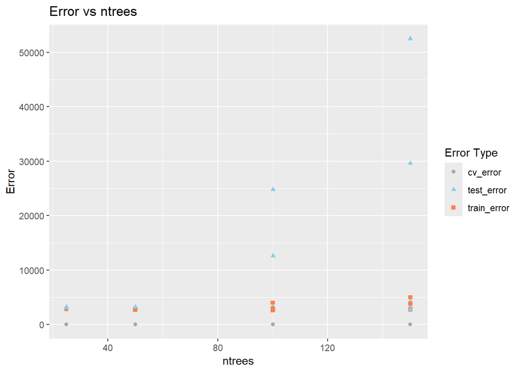

```
## [1] 397330.2
```

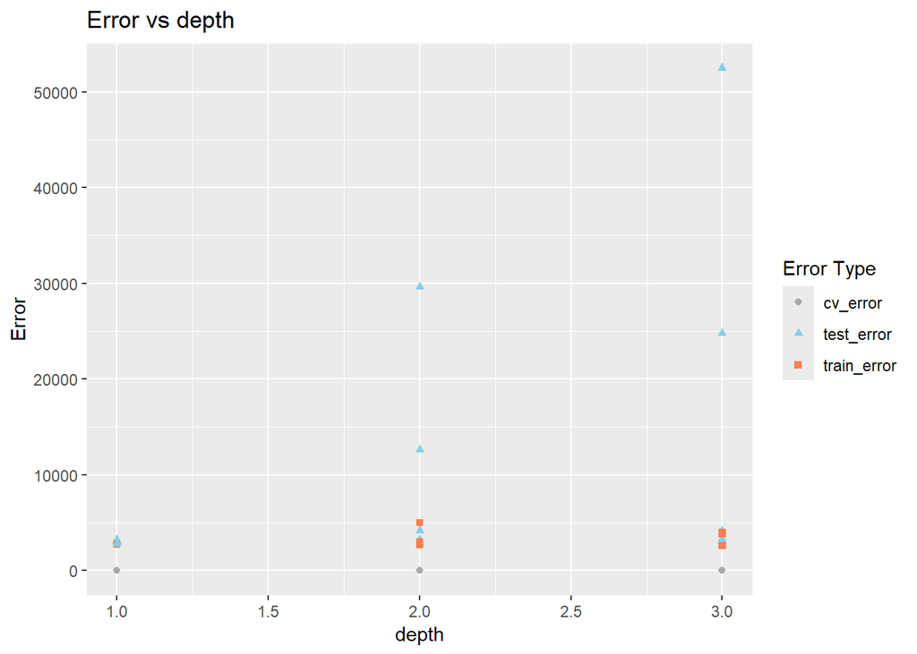

```
## [1] 397330.2
```

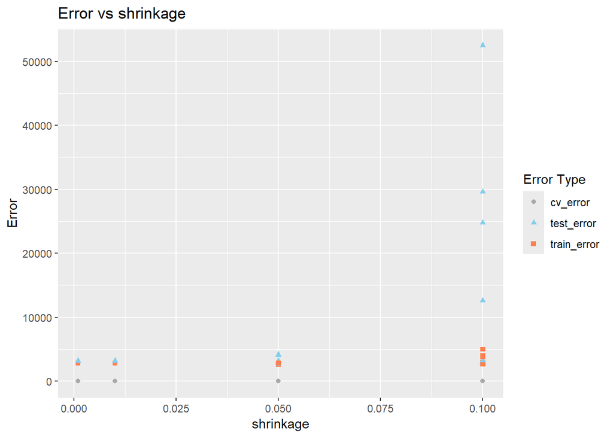

```r
#overall plot of tuners vs errs for logtransformed data
for (param in tuners) {
  plot_data <- param_tune.logtransformed %>%
    mutate(thisparam=param_tune.results[[param]]) %>% select(-all_of(tuners)) %>%
    pivot_longer(cols=c("cv_error", "train_error", "test_error"),
                 names_to = "Error_Type",
                 values_to = "Error") %>%
    mutate(Error_Type = as.factor(Error_Type));
  print(sum(plot_data$Error));
  plt <- ggplot(data=plot_data, mapping=aes(x=thisparam, y=Error,
                                            color=Error_Type,
                                            shape=Error_Type)) +
    geom_point() +
    labs(title = paste0("Error vs ", param),
         x=param, y="Error",
         color="Error Type",
         shape="Error Type") +
    scale_color_manual(values = c("darkgrey", "skyblue", "coral"));
  print(plt);
  ggsave(filename=paste0("out/analysis/problem3/plots/", param,
                         "_vs_error_boosting_problem3_logtransformed.png"), plot=plt);
}
```

```r
#log transformed version has higher lower cv error (in part caused by transformation)
# but higher test error for both minimum cv model and minimum test error models
print("Best parameter based on test error for nontransformed IRMJFY model:");
```

```
## [1] "Best parameter based on test error for nontransformed IRMJFY model:"
```

```r
print(param_tune.results[which.min(param_tune.results[["test_error"]]),]);
```

```
##    ntrees depth shrinkage cv_error train_error test_error
## 36    150     3      0.05 1948.149    1676.427   1962.876
```

```r
print("Best parameter based on test error for log-transformed IRMJFY model:");
```

```
## [1] "Best parameter based on test error for log-transformed IRMJFY model:"
```

```r
print(param_tune.logtransformed[which.min(param_tune.logtransformed[["test_error"]]),]);
```

```
##    ntrees depth shrinkage cv_error train_error test_error
## 35    100     3      0.05 7.971519    2606.768   2705.794
```

With the log transformed version of the target, The minimum cv_error based on the log transformed data does not result in the lowest de-transformed test_error. The validation set error for the transformed data fluctuates and in general is higher than similar models that just use the raw target variable, days of marijuana use in the past year. While there is some concern about the effectiveness of a treebased model to make decisions about a heavily skewed, nonnormal target variable, the log transformation is not effective in significantly normalizing the data, or in improving the model.

```r
# save file with evaluations metrics for all models and problems
write.csv(test_errs, "out/analysis/Validation_set_error_all_problems_models.csv",
          row.names = FALSE);
```